# SRKW Sightings During and After Recreational Fishing

Meghan Roberts

2023-10-20

## Summary Finding

**There seems to be no clear change in where SRKW are found when the recreational Chinook fishery in MA 7 open as opposed to when it is closed.**

## SRKW Sightings by Year

### 2022

In 2022, the recreational Chinook fishery in MA 7 was open for nine days total. It was structured as three, three day long openers. The dates were July 13-15, July 21-23, and July 28-30. There were no vessel incidents between boaters and SRKWs in this time frame.

All sightings data for when the fishery is open comes from four days: July 13th (Wednesday), July 23rd (Saturday), July 28th (Thursday) and July 29th (Friday). Whereas, the sightings data for when the fishery is closed comes three days: August 4th (Thursday), August 5th (Friday) and August 6th (Saturday).

This map demonstrates how SRKW sightings occur in different locations when the recreational fishery is open as compared to when it is closed. Specifically, the region south of San Juan Island has more sightings when the fishery is closed compared to when it is open. But it is possible, given the limited number of days with SRKW sightings, that this difference is random and not attributed to the fishery presence.

Aerial survey data was filtered to only include the days when SRKW were present in MA 7. On these days, vessels are present in the same regions as SRKW.

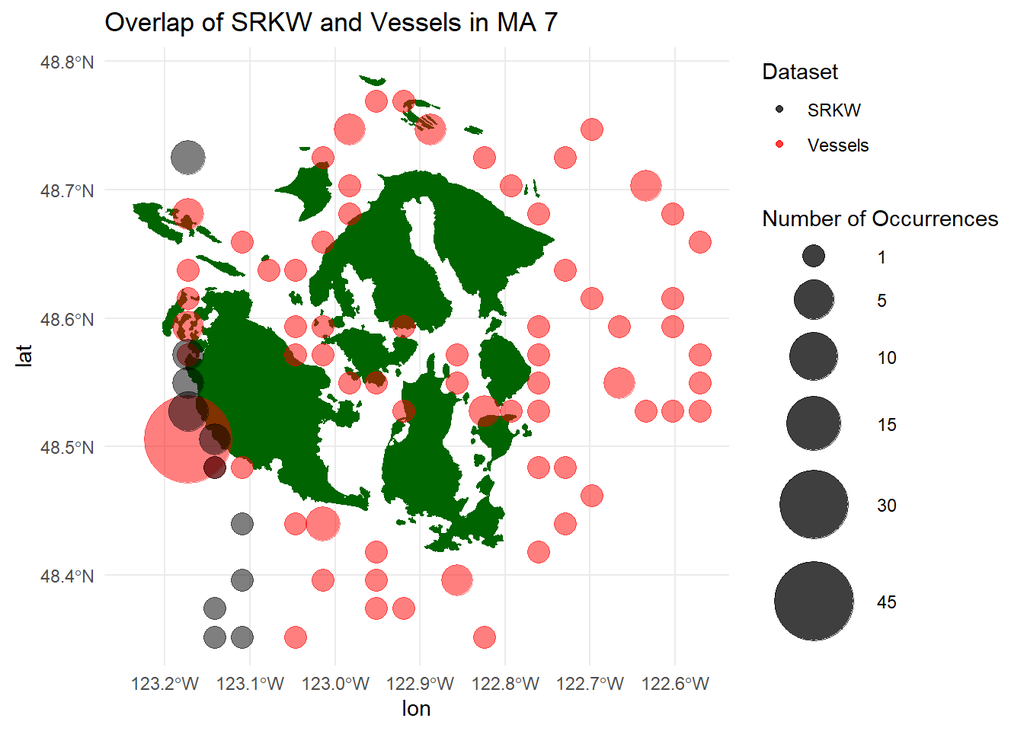

[interactive chart not shown]

### 2021

In 2021, the recreational Chinook fishery in MA 7 was open for seven days total. It was open from July 1st to July 7th. There was one vessel incident between recreational boaters and SRKWs on July 1st. There were no other vessel incidents on days when the recreational Chinook fishery was open in 2021.

When the fishery was open, SRKW sightings data only exists for July 1st (Thursday) and 2nd (Friday). The next day that had sightings with actual coordinates (as opposed to center of quadrant coordinates) was July 27th (Tuesday) which had one sighting and August 30th (Monday) which had three sightings. Due to the temporal lag of the next sightings it does not make sense to compare whale distribution during and after recreational fishing. There are also no sightings right before the fishery opens to compare to.

### 2020

In 2020, the recreational Chinook fishery in MA 7 was open for the entire month of July and the last ten days of August (22-31). There were 16 vessel incidents total between boaters and SRKWs when the recreational fishery was open spread across eight days.

When the recreational fishery was open, there were are many (>200) observations of SRKW in MA 7. But there was only one recorded sighting of SRKW in MA 7 in the first 3 weeks of August when the fishery was closed, so sightings from the month of September were used to contrast with SRKW sightings when the fishery was open. The distribution of SRKW does not change drastically when comparing sightings when the fishery was open to when the fishery was closed. There are more observations when the fishery was open as compared to when it was closed so this could explain why the distribution is slightly different. It is also important to note that SRKW use of this region changes temporally, so their use in September could be different than it is in July and the last week of August.

Aerial survey data was filtered to only include the days when SRKW were present in MA 7. On these days, vessels are present in the same regions as SRKW.

[interactive chart not shown]

### 2019

In 2019, the recreational Chinook fishery in MA 7 was open for the entire month of July. There were 5 vessel incidents between boaters and SRKWs on July 5th.

All sightings data for when the fishery is open comes from two days: July 5th (Friday) and July 6th (Saturday). The month of August was used as a comparison to show where the SRKW were when the fishery was closed. In August, there is SRKW sightings data in MA 7 for ten days. August 16th (Friday) and August 17th (Saturday) were the first set of days in August that SRKW were found in MA 7. These days are plotted as the days the fishery was closed.

This map demonstrates how SRKW sightings occur in similar locations when the recreational fishery is open as compared to when it is closed. Specifically, the region south of San Juan Island has a similar number sightings when the fishery is closed compared to when it is open.

Aerial survey data was filtered to only include the days when SRKW were present in MA 7. On these days, vessels are present in the same regions as SRKW.

[interactive chart not shown]

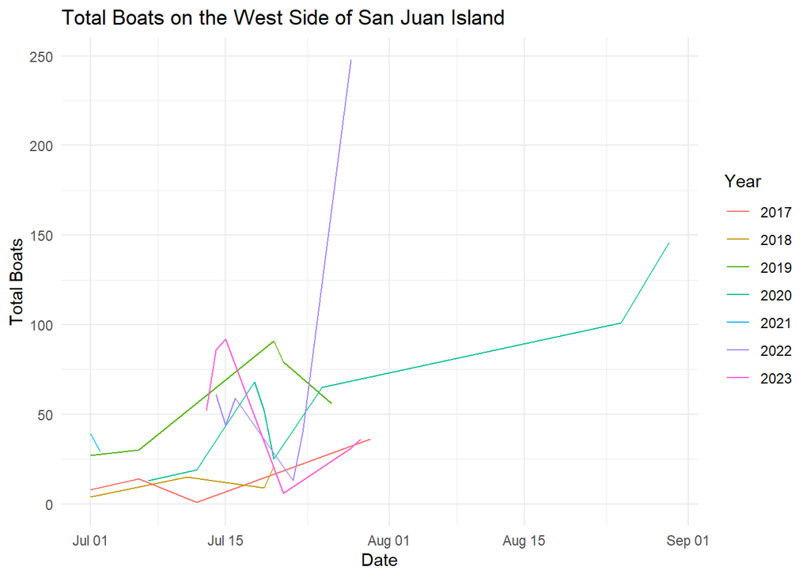

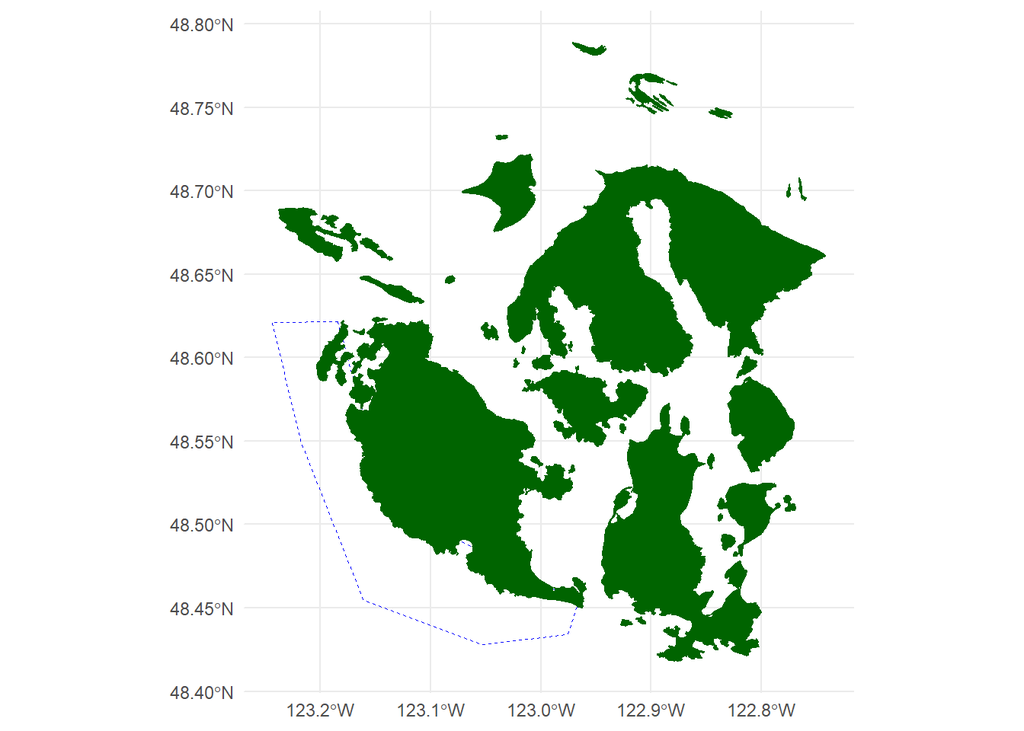

## Determine location of the boats on 2019-07-25 and in 2021

none are on the west side of SJI

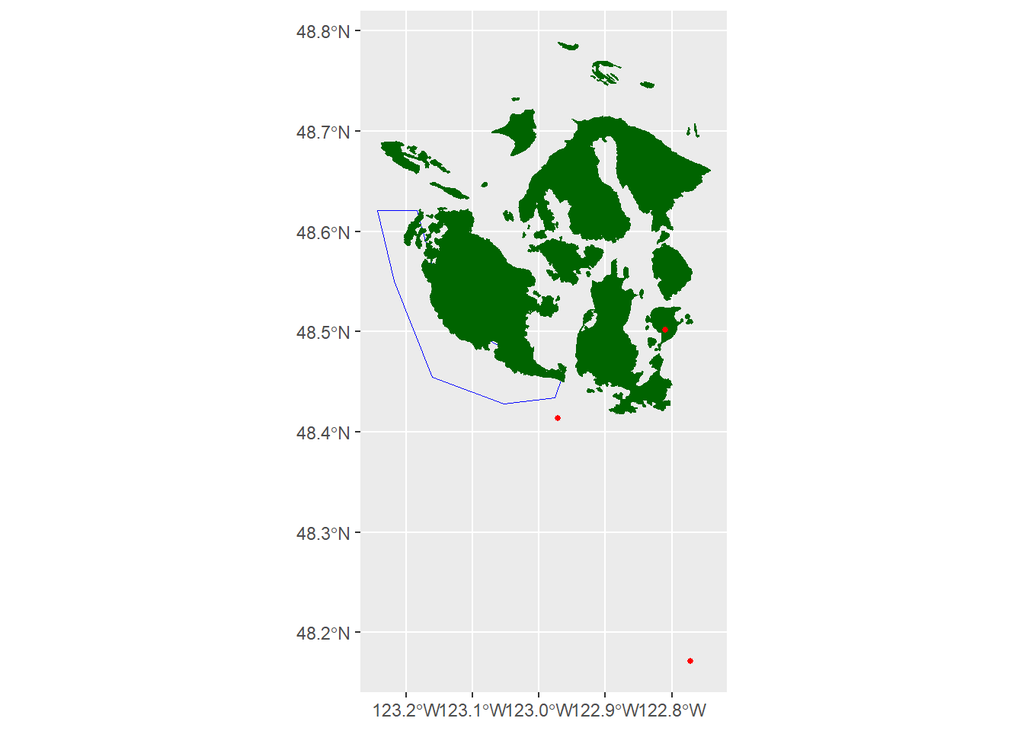

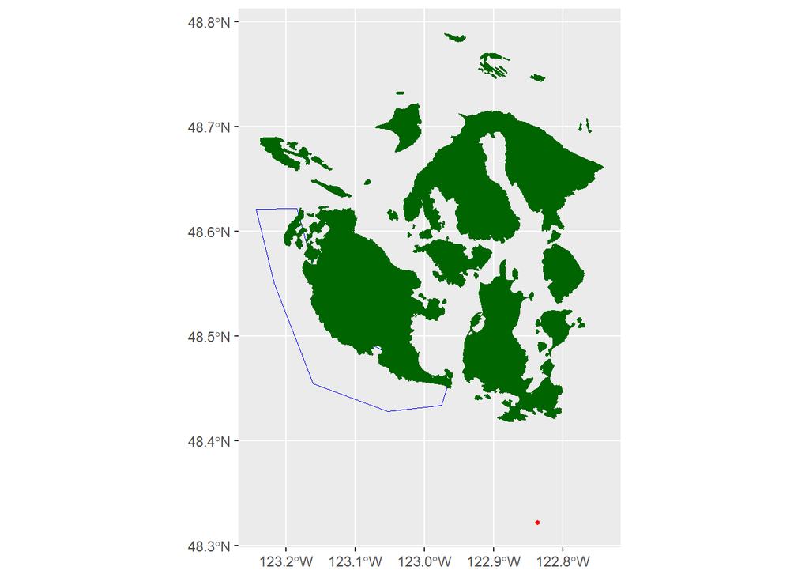